# Project 1

Logan Suchniak and Garrett Halford

3/25/2020

```r
library(readxl)
housing <- read_excel("Housing.xlsx")
#View(housing)
head(housing)
```

```
## # A tibble: 6 x 11
##      id price  size   lot  bath bedrooms yearbuilt agestandardized garagesize
##   <dbl> <dbl> <dbl> <dbl> <dbl>    <dbl>     <dbl>           <dbl>      <dbl>
## 1     1  388   2.18     4     3        4      1940            -3            0
## 2     2  450   2.05     5     3        4      1957            -1.3          2
## 3     3  386   2.11     5     2        4      1955            -1.5          2
## 4     4  350   1.44     6     1        2      1956            -1.4          1
## 5     5  156.  1.8      1     2        4      1994             2.4          1
## 6     6  220   1.96     5     2        3      1940            -3            1
## # … with 2 more variables: status <chr>, elem <chr>
```

# 1.

# Data Summary

```r
sapply(housing, class)
```

```
##              id           price            size             lot            bath
##       "numeric"       "numeric"       "numeric"       "numeric"       "numeric"
##        bedrooms       yearbuilt agestandardized      garagesize          status
##       "numeric"       "numeric"       "numeric"       "numeric"     "character"
##            elem
##     "character"
```

```r
str(housing)
```

```
## Classes 'tbl_df', 'tbl' and 'data.frame':    76 obs. of  11 variables:
##  $ id             : num  1 2 3 4 5 6 7 8 9 10 ...
##  $ price          : num  388 450 386 350 156 ...
##  $ size           : num  2.18 2.05 2.11 1.44 1.8 ...
##  $ lot            : num  4 5 5 6 1 5 4 4 4 5 ...
##  $ bath           : num  3 3 2 1 2 2 1.1 2 2.1 2.1 ...
##  $ bedrooms       : num  4 4 4 2 4 3 4 4 4 3 ...
##  $ yearbuilt      : num  1940 1957 1955 1956 1994 ...
##  $ agestandardized: num  -3 -1.3 -1.5 -1.4 2.4 -3 -1.2 -0.9 -0.5 -0.2 ...
##  $ garagesize     : num  0 2 2 1 1 1 1 2 2 2 ...
##  $ status         : chr  "sld" "sld" "sld" "act" ...
##  $ elem           : chr  "edison" "edison" "edison" "adams" ...
```

```r
housing.numeric <- housing[, sapply(housing, is.numeric)]
apply(housing.numeric, 2, mean)
```

```
##              id           price            size             lot            bath
##     38.50000000    285.79539474      1.97039474      3.98684211      2.20789474
##        bedrooms       yearbuilt agestandardized      garagesize
##      3.44736842   1969.40789474     -0.05921053      1.56578947
```

```r
apply(housing.numeric, 2, sd)
```

```
##              id           price            size             lot            bath
##      22.0831761      60.3326855       0.2124200       1.6532265       0.5703246
##        bedrooms       yearbuilt agestandardized      garagesize
##       0.7374684      23.4925109       2.3492511       0.7717603
```

```r
apply(housing.numeric, 2, range)
```

```
##      id price  size lot bath bedrooms yearbuilt agestandardized garagesize
## [1,]  1 155.5 1.440   1  1.0        2      1905            -6.5          0
## [2,] 76 450.0 2.896  11  3.1        6      2005             3.5          3
```

After looking at the data in various ways above, it seems that there are no missing values and the data does not look to have any typos or strange values. The values that require extra explanation are price, size and lot:

-The price of the house seems to be recorded as a dollar amount in the thousands, so a house with a price value of 388 really means $388,000.

-The size of the house is most likely recorded in square feet multiplied by 1000, so a house with a 2.000 size really means 2,000 square feet.

-The lot variable is probably recorded in acres.

```r
attach(housing)
```

# 2.

# Exploratory Data Analysis

```r
summary(lm(price~size))
```

```
##
## Call:
## lm(formula = price ~ size)
##
## Residuals:
##      Min       1Q   Median       3Q      Max
## -120.547  -40.848   -7.604   48.484  159.421
##
## Coefficients:
##             Estimate Std. Error t value Pr(>|t|)
## (Intercept)   173.06      64.09   2.700  0.00858 **
## size           57.21      32.34   1.769  0.08100 .
## ---
## Signif. codes:  0 '***' 0.001 '**' 0.01 '*' 0.05 '.' 0.1 ' ' 1
##
## Residual standard error: 59.49 on 74 degrees of freedom
## Multiple R-squared:  0.04058,    Adjusted R-squared:  0.02761
## F-statistic:  3.13 on 1 and 74 DF,  p-value: 0.081
```

This shows that there is not a significant relationship between size and the price of a house due to the large p value of 0.081.

```r
summary(lm(housing$price~housing$lot))
```

```
##
## Call:
## lm(formula = housing$price ~ housing$lot)
##
## Residuals:
##      Min       1Q   Median       3Q      Max
## -103.674  -44.926   -9.456   48.240  155.174
##
## Coefficients:
##             Estimate Std. Error t value Pr(>|t|)
## (Intercept)  250.261     17.738  14.108   <2e-16 ***
## housing$lot    8.913      4.114   2.167   0.0335 *
## ---
## Signif. codes:  0 '***' 0.001 '**' 0.01 '*' 0.05 '.' 0.1 ' ' 1
##
## Residual standard error: 58.9 on 74 degrees of freedom
## Multiple R-squared:  0.05965,    Adjusted R-squared:  0.04694
## F-statistic: 4.694 on 1 and 74 DF,  p-value: 0.03349
```

This shows that there is a significant relationship between the size of the lot surrounding a house with the price of the house. This can be seen by the small p value of 0.0335.

```r
summary(lm(price~bath))
```

```
##
## Call:
## lm(formula = price ~ bath)
##
## Residuals:
##     Min      1Q  Median      3Q     Max
## -126.45  -35.78  -13.03   41.20  153.05
##
## Coefficients:
##             Estimate Std. Error t value Pr(>|t|)
## (Intercept)   245.00      27.60   8.877 2.84e-13 ***
## bath           18.48      12.11   1.526    0.131
## ---
## Signif. codes:  0 '***' 0.001 '**' 0.01 '*' 0.05 '.' 0.1 ' ' 1
##
## Residual standard error: 59.81 on 74 degrees of freedom
## Multiple R-squared:  0.03051,    Adjusted R-squared:  0.0174
## F-statistic: 2.328 on 1 and 74 DF,  p-value: 0.1313
```

Due to the large p value of 0.131, it can be determined that there is not a significant relationship between the number of bathrooms and the price of the house.

```r
summary(lm(price~bedrooms))
```

```
##
## Call:
## lm(formula = price ~ bedrooms)
##
## Residuals:
##      Min       1Q   Median       3Q      Max
## -117.356  -40.417   -7.213   40.480  177.144
##
## Coefficients:
##             Estimate Std. Error t value Pr(>|t|)
## (Intercept)  366.512     32.116  11.412   <2e-16 ***
## bedrooms     -23.414      9.112  -2.569   0.0122 *
## ---
## Signif. codes:  0 '***' 0.001 '**' 0.01 '*' 0.05 '.' 0.1 ' ' 1
##
## Residual standard error: 58.2 on 74 degrees of freedom
## Multiple R-squared:  0.08191,    Adjusted R-squared:  0.0695
## F-statistic: 6.602 on 1 and 74 DF,  p-value: 0.0122
```

By looking at the small p value of 0.0122, it can be seen that the relationship between the number of bedrooms and the price of the house is significant.

```r
summary(lm(price~agestandardized))
```

```
##
## Call:
## lm(formula = price ~ agestandardized)
##
## Residuals:
##     Min      1Q  Median      3Q     Max
## -140.03  -36.96  -10.47   44.85  169.12
##
## Coefficients:
##                 Estimate Std. Error t value Pr(>|t|)
## (Intercept)      286.030      6.886  41.537   <2e-16 ***
## agestandardized    3.958      2.950   1.342    0.184
## ---
## Signif. codes:  0 '***' 0.001 '**' 0.01 '*' 0.05 '.' 0.1 ' ' 1
##
## Residual standard error: 60.01 on 74 degrees of freedom
## Multiple R-squared:  0.02375,    Adjusted R-squared:  0.01056
## F-statistic: 1.801 on 1 and 74 DF,  p-value: 0.1837
```

This shows that the age of the house does not have a significant relationship with the respective price. The p value is considered large by being 0.184.

```r
summary(lm(price~garagesize))
```

```
##
## Call:
## lm(formula = price ~ garagesize)
##
## Residuals:
##     Min      1Q  Median      3Q     Max
## -114.44  -38.96  -13.96   42.30  152.04
##
## Coefficients:
##             Estimate Std. Error t value Pr(>|t|)
## (Intercept)  241.927     14.791  16.356  < 2e-16 ***
## garagesize    28.017      8.484   3.302  0.00148 **
## ---
## Signif. codes:  0 '***' 0.001 '**' 0.01 '*' 0.05 '.' 0.1 ' ' 1
##
## Residual standard error: 56.7 on 74 degrees of freedom
## Multiple R-squared:  0.1284, Adjusted R-squared:  0.1167
## F-statistic: 10.91 on 1 and 74 DF,  p-value: 0.001479
```

By observing the small p value of 0.00148, it can be determined that the relationship between the garage size and the price of the house is signifcant.

```r
summary(lm(price~status))
```

```
##
## Call:
## lm(formula = price ~ status)
##
## Residuals:
##     Min      1Q  Median      3Q     Max
## -113.71  -39.82  -15.37   38.97  180.79
##
## Coefficients:
##             Estimate Std. Error t value Pr(>|t|)
## (Intercept)  301.526     11.752  25.657   <2e-16 ***
## statuspen      2.489     20.092   0.124   0.9017
## statussld    -32.313     15.132  -2.135   0.0361 *
## ---
## Signif. codes:  0 '***' 0.001 '**' 0.01 '*' 0.05 '.' 0.1 ' ' 1
##
## Residual standard error: 58.76 on 73 degrees of freedom
## Multiple R-squared:  0.07674,    Adjusted R-squared:  0.05145
## F-statistic: 3.034 on 2 and 73 DF,  p-value: 0.05424
```

The large p value of 0.05424 explains that the model is not significant. We can determine that status as a whole is not significant predictor.

```r
summary(lm(housing$price~housing$elem))
```

```
##
## Call:
## lm(formula = housing$price ~ housing$elem)
##
## Residuals:
##     Min      1Q  Median      3Q     Max
## -92.100 -42.187  -1.602  30.206 165.242
##
## Coefficients:
##                    Estimate Std. Error t value Pr(>|t|)
## (Intercept)          241.83      31.81   7.604  9.8e-11 ***
## housing$elemcrest     45.98      38.95   1.180   0.2418
## housing$elemedge      27.92      33.59   0.831   0.4086
## housing$elemedison    85.27      35.56   2.398   0.0192 *
## housing$elemharris    77.27      35.05   2.205   0.0308 *
## housing$elemparker    15.61      34.84   0.448   0.6554
## ---
## Signif. codes:  0 '***' 0.001 '**' 0.01 '*' 0.05 '.' 0.1 ' ' 1
##
## Residual standard error: 55.09 on 70 degrees of freedom
## Multiple R-squared:  0.2219, Adjusted R-squared:  0.1663
## F-statistic: 3.992 on 5 and 70 DF,  p-value: 0.003042
```

The small p value of 0.003042 allows us to determine that the model is significant. Elem should be included in the final model.

# 3.

# Initial Modeling

```r
lg<-lm(price~lot+bedrooms+garagesize+elem,data=housing)
summary(lg)
```

```
##
## Call:
## lm(formula = price ~ lot + bedrooms + garagesize + elem, data = housing)
##
## Residuals:
##      Min       1Q   Median       3Q      Max
## -100.908  -33.040    1.714   30.484   97.970
##
## Coefficients:
##             Estimate Std. Error t value Pr(>|t|)
## (Intercept)  199.606     44.700   4.465 3.14e-05 ***
## lot            9.822      3.760   2.612  0.01109 *
## bedrooms      -6.592      8.675  -0.760  0.45000
## garagesize    22.714      8.357   2.718  0.00835 **
## elemcrest     36.258     34.606   1.048  0.29852
## elemedge      13.235     30.244   0.438  0.66308
## elemedison    84.252     31.357   2.687  0.00909 **
## elemharris    70.188     31.489   2.229  0.02917 *
## elemparker     2.871     31.232   0.092  0.92704
## ---
## Signif. codes:  0 '***' 0.001 '**' 0.01 '*' 0.05 '.' 0.1 ' ' 1
##
## Residual standard error: 47.65 on 67 degrees of freedom
## Multiple R-squared:  0.4427, Adjusted R-squared:  0.3762
## F-statistic: 6.653 on 8 and 67 DF,  p-value: 2.253e-06
```

$$Price=199.606+9.822(lot)-6.592(bedrooms)+22.714(garagesize)+36.258(elemcrest)+13.235(elemedge)+84.252(elemedison)+70.188(elemharris)+2.871(elemparker)$$
This is the intial linear regression equation used in order to estimate the price of a house.

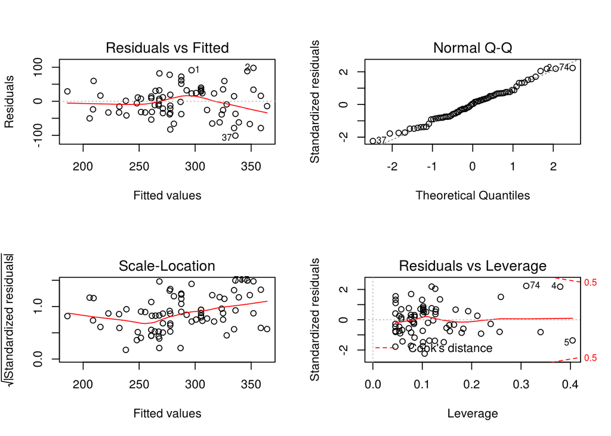

```r
par(mfrow=c(2,2))
plot(lg)
```

These plots show us that the data is not entirely normal or linear and can be manipulated to create a better model. For example, the residuals vs. fitted plot has a peak and then a downward trend when the ideal plot would just be a straight line. Additionally, the qq and scale-location plots are not entirely straight.

# 4.

# Model Modification

```r
housing1 <- subset(housing, lot<8)
housing2 <- housing1[c(-4), ]
```

The first part of the data modification was to remove points that were determined to be outliars.

```r
pow<-1/2
pricet<-(housing2$price)^pow
```

This input was included in order to fix problems with non linearity.

```r
lg2<-lm(pricet~sqrt(lot)+bedrooms+garagesize+elem,data = housing2)
summary(lg2)
```

```
##
## Call:
## lm(formula = pricet ~ sqrt(lot) + bedrooms + garagesize + elem,
##     data = housing2)
##
## Residuals:
##      Min       1Q   Median       3Q      Max
## -2.60371 -0.88796  0.06165  0.67923  2.81833
##
## Coefficients:
##             Estimate Std. Error t value Pr(>|t|)
## (Intercept)  12.9646     1.5426   8.404 6.26e-12 ***
## sqrt(lot)     0.2205     0.4483   0.492 0.624474
## bedrooms     -0.1494     0.2451  -0.610 0.544293
## garagesize    0.8526     0.2321   3.673 0.000492 ***
## elemcrest     2.8936     1.0945   2.644 0.010300 *
## elemedge      1.8137     0.9799   1.851 0.068804 .
## elemedison    4.0713     1.0098   4.032 0.000150 ***
## elemharris    3.4528     1.0017   3.447 0.001007 **
## elemparker    1.8249     1.0095   1.808 0.075359 .
## ---
## Signif. codes:  0 '***' 0.001 '**' 0.01 '*' 0.05 '.' 0.1 ' ' 1
##
## Residual standard error: 1.306 on 64 degrees of freedom
## Multiple R-squared:  0.4974, Adjusted R-squared:  0.4345
## F-statistic: 7.916 on 8 and 64 DF,  p-value: 2.433e-07
```

In this model, we created pricet in order to fix problems with linearity. We then took the sqare root of all lot values in order to condense the spread of values and hopefully create a straighter qq plot. We used housing2 as our data set because that was the set that exluded the variables we believed to be outliars. Our R-squared statistic is 0.4974. This means that 49.74% of the variation in price can be explained by the variation in lot, bedrooms, garagesize and elem. The models overall p value is 2.433-07.

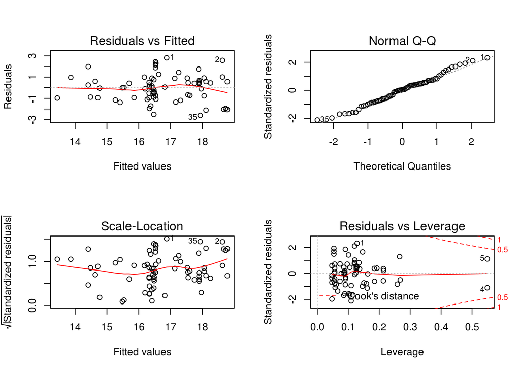

```r
par(mfrow=c(2,2))
plot(lg2)
```

The model after modification produces plots that indicate slightly more normal and linear data. The residual vs leverage plot brings out points 4 and 5 to be examined. There is no obvious fanning of the residual points in the scale location plot.

# 5.

# Conclusion

```r
library(car)
vif(lg2)
```

```
##                GVIF Df GVIF^(1/(2*Df))
## sqrt(lot)  1.288221  1        1.134998
## bedrooms   1.276345  1        1.129754
## garagesize 1.329732  1        1.153140
## elem       1.446926  5        1.037635
```

```r
confint(lg2)
```

```
##                  2.5 %     97.5 %
## (Intercept)  9.8828907 16.0463617
## sqrt(lot)   -0.6750437  1.1160663
## bedrooms    -0.6389326  0.3401692
## garagesize   0.3888494  1.3163414
## elemcrest    0.7070734  5.0801600
## elemedge    -0.1439118  3.7713555
## elemedison   2.0540299  6.0884910
## elemharris   1.4515618  5.4539720
## elemparker  -0.1918796  3.8416173
```

```r
#View(housing2)
```

```r
elem <- factor(housing2$elem, levels=c("edge","edison","parker","harris","crest","adams"))
```

```r
newdata<-data.frame(lot=4,bedrooms=4,garagesize=5,elem="edison")


predict(lg2, newdata, interval = "confidence")
```

```
##        fit      lwr      upr
## 1 21.14236 19.17883 23.10589
```

```r
19.17883^2
```

```
## [1] 367.8275
```

```r
23.10589^2
```

```
## [1] 533.8822
```

```r
predict(lg2, newdata, interval = "predict")
```

```
##        fit      lwr      upr
## 1 21.14236 17.87716 24.40755
```

```r
17.87716^2
```

```
## [1] 319.5928
```

```r
24.40755^2
```

```
## [1] 595.7285
```

The 95% confidence interval for the house with our chosen qualities lies between 368,000 dollars and 534,000 dollars.

The 95% prediction interval for the same house predicts a cost between 320,000 dollars and 596,000 dollars.

The output price values were squared to compensate for the modelling alterations to the price variable.

Our model seems relatively reasonable as the house we chose to predict the cost of had a four acre lot, four bedrooms, and a five car garage. Additionally, the house is in the Edison school zone which seems to raise the value of the house.